# Biostat776_Project_1

CanWang

2024-09-10

## Data

```r
library("tidyverse")
## Install the tidytuesdayR package if you don't have it
if (!require("tidytuesdayR", quietly = TRUE)) {
    install.packages("tidytuesdayR")
}

## For the GitHub version of tidytuesdayR (in case the CRAN version is not available)
## you'll need the "remotes" package to install it.
## See for example https://github.com/dslc-io/tidytuesdayR/issues/94 which led
## to tidytuesdayR not been available from CRAN at the end of August 2024
## Install the remotes package if you don't have it
if (!require("remotes", quietly = TRUE)) {
    install.packages("remotes")
}
## Install the tidytuesdayR package (from GitHub) if you don't have it
if (!require("tidytuesdayR", quietly = TRUE)) {
    remotes::install_github("dslc-io/tidytuesdayR")
}
```

```r
library("here")
library("tidyverse")

# tests if a directory named "data" exists locally
if (!dir.exists(here("data"))) {
    dir.create(here("data"))
}

# saves data only once (not each time you knit a R Markdown)
if (!file.exists(here("data", "chocolate.RDS"))) {
    url_csv <- "https://raw.githubusercontent.com/rfordatascience/tidytuesday/master/data/2022/2022-01-18/chocolate.csv"
    chocolate <- readr::read_csv(url_csv)

    # save the file to RDS objects
    saveRDS(chocolate, file = here("data", "chocolate.RDS"))
}
```

```r
chocolate <- readRDS(here("data", "chocolate.RDS"))
as_tibble(chocolate)
```

```
## # A tibble: 2,530 × 10
##      ref company_manufacturer company_location review_date
##    <dbl> <chr>                <chr>                  <dbl>
##  1  2454 5150                 U.S.A.                  2019
##  2  2458 5150                 U.S.A.                  2019
##  3  2454 5150                 U.S.A.                  2019
##  4  2542 5150                 U.S.A.                  2021
##  5  2546 5150                 U.S.A.                  2021
##  6  2546 5150                 U.S.A.                  2021
##  7  2542 5150                 U.S.A.                  2021
##  8   797 A. Morin             France                  2012
##  9   797 A. Morin             France                  2012
## 10  1011 A. Morin             France                  2013
## # ℹ 2,520 more rows
## # ℹ 6 more variables: country_of_bean_origin <chr>,
## #   specific_bean_origin_or_bar_name <chr>, cocoa_percent <chr>,
## #   ingredients <chr>, most_memorable_characteristics <chr>, rating <dbl>
```

```r
glimpse(chocolate)
```

```
## Rows: 2,530
## Columns: 10
## $ ref                              <dbl> 2454, 2458, 2454, 2542, 2546, 2546, 2…
## $ company_manufacturer             <chr> "5150", "5150", "5150", "5150", "5150…
## $ company_location                 <chr> "U.S.A.", "U.S.A.", "U.S.A.", "U.S.A.…
## $ review_date                      <dbl> 2019, 2019, 2019, 2021, 2021, 2021, 2…
## $ country_of_bean_origin           <chr> "Tanzania", "Dominican Republic", "Ma…
## $ specific_bean_origin_or_bar_name <chr> "Kokoa Kamili, batch 1", "Zorzal, bat…
## $ cocoa_percent                    <chr> "76%", "76%", "76%", "68%", "72%", "8…
## $ ingredients                      <chr> "3- B,S,C", "3- B,S,C", "3- B,S,C", "…
## $ most_memorable_characteristics   <chr> "rich cocoa, fatty, bready", "cocoa, …
## $ rating                           <dbl> 3.25, 3.50, 3.75, 3.00, 3.00, 3.25, 3…
```

# Part 1: Explore data

### 1. Make a histogram of the rating scores to visualize the overall distribution of scores. Change the number of bins from the default to 10, 15, 20, and 25. Pick on the one that you think looks the best. Explain what the difference is when you change the number of bins and explain why you picked the one you did.

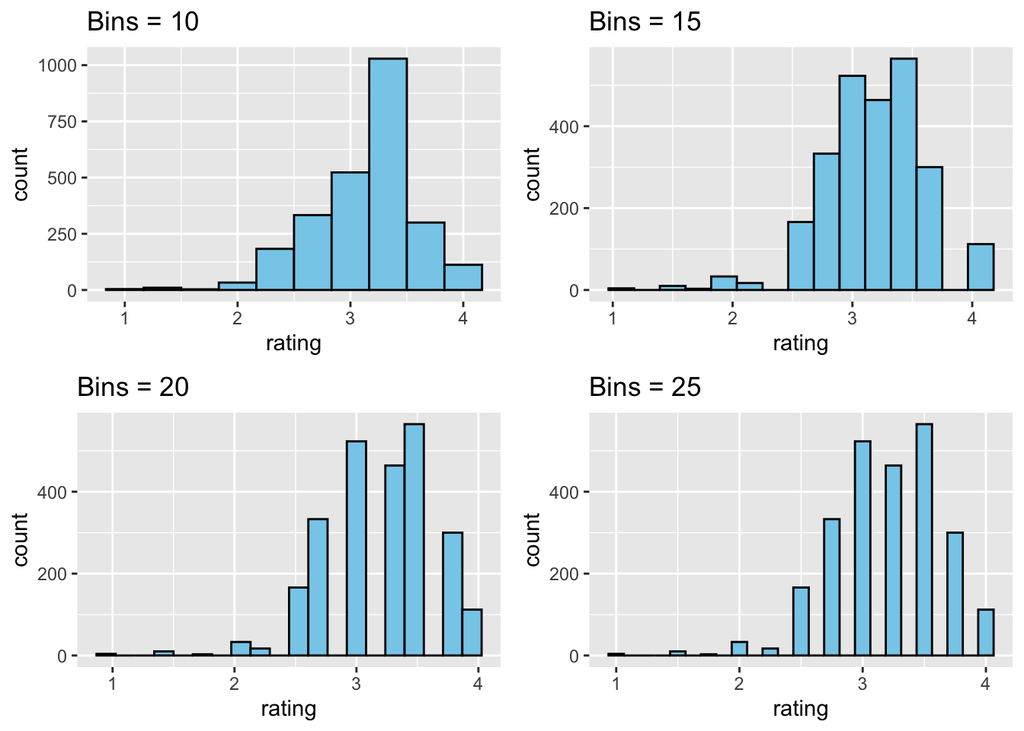

```r
library(ggplot2)
library(gridExtra)
bins = c(10,15,20,25)
plot_hist <- function(bins){
  ggplot(chocolate, aes(x=rating)) + geom_histogram(bins=bins,fill = "skyblue",color = "black") + ggtitle(paste("Bins =", bins))
}
plots <- lapply(bins, plot_hist)
grid.arrange(grobs = plots, ncol = 2, nrow = 2)
```

As the number of bins increases, the shape of the histogram changes, and it shows more details of the distribution. I pick the last one with bins=25 because it shows the shape of the distribution well, and the positions of the bins correspond with the real discreate values of rating.

### 2. Consider the countries where the beans originated from. How many reviews come from each country of bean origin?

```r
chocolate %>%
  group_by(country_of_bean_origin) %>%
  summarise(count=n())
```

```
## # A tibble: 62 × 2
##    country_of_bean_origin count
##    <chr>                  <int>
##  1 Australia                  3
##  2 Belize                    76
##  3 Blend                    156
##  4 Bolivia                   80
##  5 Brazil                    78
##  6 Burma                      1
##  7 Cameroon                   3
##  8 China                      1
##  9 Colombia                  79
## 10 Congo                     11
## # ℹ 52 more rows
```

### 3. What is average rating scores from reviews of chocolate bars that have Ecuador as country_of_bean_origin in this dataset? For this same set of reviews, also calculate (1) the total number of reviews and (2) the standard deviation of the rating scores. Your answer should be a new data frame with these three summary statistics in three columns. Label the name of these columns mean, sd, and total.

```r
chocolate_Ecuador <- filter(chocolate,country_of_bean_origin=="Ecuador")
chocolate_Ecuador %>%
  summarise(mean=mean(rating),sd=sd(rating),total=n())
```

```
## # A tibble: 1 × 3
##    mean    sd total
##   <dbl> <dbl> <int>
## 1  3.16 0.512   219
```

### 4. Which company (name) makes the best chocolate (or has the highest ratings on average) with beans from Ecuador?

```r
filter(chocolate_Ecuador,rating == as.numeric(summarise(chocolate_Ecuador,max(rating))))$company_manufacturer
```

```
## [1] "Amano"                  "Benoit Nihant"          "Beschle (Felchlin)"
## [4] "Domori"                 "Durci"                  "Pacari"
## [7] "Smooth Chocolator, The" "Smooth Chocolator, The"
```

### 5. Calculate the average rating across all country of origins for beans. Which top 3 countries (for bean origin) have the highest ratings on average?

```r
head(
  arrange(
    chocolate %>%
      group_by(country_of_bean_origin) %>%
      summarise(mean=mean(rating)),
  desc(mean))
,3)
```

```
## # A tibble: 3 × 2
##   country_of_bean_origin  mean
##   <chr>                  <dbl>
## 1 Tobago                  3.62
## 2 China                   3.5
## 3 Sao Tome & Principe     3.5
```

### 6. Following up on the previous problem, now remove any countries of bean origins that have less than 10 chocolate bar reviews. Now, which top 3 countries have the highest ratings on average?

```r
chocolate_country <-
  chocolate %>%
    group_by(country_of_bean_origin) %>%
    summarise(count = n(),mean=mean(rating))
#chocolate_country
head(arrange(filter(chocolate_country,count>=10),desc(mean)),3)
```

```
## # A tibble: 3 × 3
##   country_of_bean_origin count  mean
##   <chr>                  <int> <dbl>
## 1 Solomon Islands           10  3.45
## 2 Congo                     11  3.32
## 3 Cuba                      12  3.29
```

### 7. Explore the relationship between percent chocolate and ratings.

1. Identify the countries of bean origin with at least 50 reviews. Remove reviews from countries are not in this list.

```r
## Identify the countries of bean origin with at least 50 reviews.
chocolate_country_50 <- filter(chocolate_country,count>=50)
chocolate_country_50
```

```
## # A tibble: 16 × 3
##    country_of_bean_origin count  mean
##    <chr>                  <int> <dbl>
##  1 Belize                    76  3.23
##  2 Blend                    156  3.04
##  3 Bolivia                   80  3.18
##  4 Brazil                    78  3.26
##  5 Colombia                  79  3.20
##  6 Dominican Republic       226  3.22
##  7 Ecuador                  219  3.16
##  8 Guatemala                 62  3.26
##  9 Madagascar               177  3.27
## 10 Mexico                    55  3.17
## 11 Nicaragua                100  3.26
## 12 Papua New Guinea          50  3.28
## 13 Peru                     244  3.20
## 14 Tanzania                  79  3.23
## 15 Venezuela                253  3.23
## 16 Vietnam                   73  3.29
```

```r
## Remove reviews from countries are not in this list.
chocolate_50 <- filter(chocolate,country_of_bean_origin %in% chocolate_country_50$country_of_bean_origin)
chocolate_50
```

```
## # A tibble: 2,007 × 10
##      ref company_manufacturer company_location review_date
##    <dbl> <chr>                <chr>                  <dbl>
##  1  2454 5150                 U.S.A.                  2019
##  2  2458 5150                 U.S.A.                  2019
##  3  2454 5150                 U.S.A.                  2019
##  4  2546 5150                 U.S.A.                  2021
##  5   797 A. Morin             France                  2012
##  6   797 A. Morin             France                  2012
##  7  1015 A. Morin             France                  2013
##  8  1011 A. Morin             France                  2013
##  9  1011 A. Morin             France                  2013
## 10  1015 A. Morin             France                  2013
## # ℹ 1,997 more rows
## # ℹ 6 more variables: country_of_bean_origin <chr>,
## #   specific_bean_origin_or_bar_name <chr>, cocoa_percent <chr>,
## #   ingredients <chr>, most_memorable_characteristics <chr>, rating <dbl>
```

2. Using the variable describing the chocolate percentage for each review, create a new column that groups chocolate percentages into one of four groups: (i) <60%, (ii) >=60 to <70%, (iii) >=70 to <90%, and (iii) >=90%

```r
chocolate_50 <- chocolate_50 %>%
    mutate(percentage = case_when(
        as.numeric(substr(cocoa_percent,1,nchar(cocoa_percent)-1)) >= 90 ~ ">=90%",
        as.numeric(substr(cocoa_percent,1,nchar(cocoa_percent)-1)) >=70 ~ ">=70 to <90%",
        as.numeric(substr(cocoa_percent,1,nchar(cocoa_percent)-1)) >=60 ~ ">=60 to <70%",
        as.numeric(substr(cocoa_percent,1,nchar(cocoa_percent)-1)) < 60 ~ "<60%"
    ))
chocolate_50
```

```
## # A tibble: 2,007 × 11
##      ref company_manufacturer company_location review_date
##    <dbl> <chr>                <chr>                  <dbl>
##  1  2454 5150                 U.S.A.                  2019
##  2  2458 5150                 U.S.A.                  2019
##  3  2454 5150                 U.S.A.                  2019
##  4  2546 5150                 U.S.A.                  2021
##  5   797 A. Morin             France                  2012
##  6   797 A. Morin             France                  2012
##  7  1015 A. Morin             France                  2013
##  8  1011 A. Morin             France                  2013
##  9  1011 A. Morin             France                  2013
## 10  1015 A. Morin             France                  2013
## # ℹ 1,997 more rows
## # ℹ 7 more variables: country_of_bean_origin <chr>,
## #   specific_bean_origin_or_bar_name <chr>, cocoa_percent <chr>,
## #   ingredients <chr>, most_memorable_characteristics <chr>, rating <dbl>,
## #   percentage <chr>
```

3. Using the new column described in #2, re-order the factor levels (if needed) to be starting with the smallest percentage group and increasing to the largest percentage group.

```r
library(forcats)
chocolate_50$percentage <- as.factor(chocolate_50$percentage)
chocolate_50$percentage <- fct_relevel(chocolate_50$percentage, "<60%", ">=60 to <70%", ">=70 to <90%", ">=90%")
levels(chocolate_50$percentage)
```

```
## [1] "<60%"         ">=60 to <70%" ">=70 to <90%" ">=90%"
```

4. For each country, make a set of four side-by-side boxplots plotting the groups on the x-axis and the ratings on the y-axis. These plots should be faceted by country.

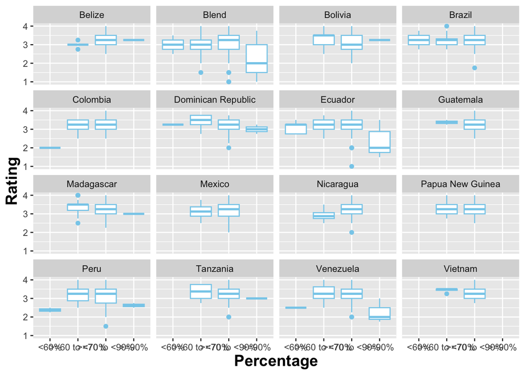

```r
ggplot(chocolate_50, aes(x = percentage, y = rating)) +
  geom_boxplot(color="skyblue")+
  theme(axis.title = element_text(size = 15,
                                  color = "black",
                                  face = "bold"))+
  facet_wrap(~country_of_bean_origin)+
  labs(x = "Percentage", y = "Rating")
```

```r
#Calculate the mean rating of each percentage group
chocolate_50 %>%
  group_by(percentage) %>%
  summarise(MeanRating=mean(rating))
```

```
## # A tibble: 4 × 2
##   percentage   MeanRating
##   <fct>             <dbl>
## 1 <60%               2.96
## 2 >=60 to <70%       3.25
## 3 >=70 to <90%       3.22
## 4 >=90%              2.49
```

From calculation, we see that on average the second group(60%-70%) has the highest rating, followed closely by the third group(70%-90%). The first(<60%) and fourth group(>=90%) has lower ratings.

From the boxplot, most countries follow this rule. The second or third group has the highest rating. But there are also several conter-examples, where the first or fourth group has higher ratings than the second or third group.

# Part 2: Join two datasets together

### 1.Use this dataset it to create a new column called continent in our chocolate dataset1 that contains the continent name for each review where the country of bean origin is.

```r
##data
library(gapminder)
##select contry and continent from gapminder
country_continent <- gapminder %>%
  select(country, continent)
#delete the repeated rows
unique_country_continent <- country_continent %>%
  distinct()
##join two datasets
merged <- chocolate %>%
  left_join(unique_country_continent %>% select(country, continent),
            by = c("country_of_bean_origin" = "country"))
merged
```

```
## # A tibble: 2,530 × 11
##      ref company_manufacturer company_location review_date
##    <dbl> <chr>                <chr>                  <dbl>
##  1  2454 5150                 U.S.A.                  2019
##  2  2458 5150                 U.S.A.                  2019
##  3  2454 5150                 U.S.A.                  2019
##  4  2542 5150                 U.S.A.                  2021
##  5  2546 5150                 U.S.A.                  2021
##  6  2546 5150                 U.S.A.                  2021
##  7  2542 5150                 U.S.A.                  2021
##  8   797 A. Morin             France                  2012
##  9   797 A. Morin             France                  2012
## 10  1011 A. Morin             France                  2013
## # ℹ 2,520 more rows
## # ℹ 7 more variables: country_of_bean_origin <chr>,
## #   specific_bean_origin_or_bar_name <chr>, cocoa_percent <chr>,
## #   ingredients <chr>, most_memorable_characteristics <chr>, rating <dbl>,
## #   continent <fct>
```

### 2. Only keep reviews that have reviews from countries of bean origin with at least 10 reviews.

```r
## Identify the countries of bean origin with at least 10 reviews.
chocolate_country_10 <- filter(chocolate_country,count>=10)
## Remove reviews from countries are not in this list.
merged_10 <- filter(merged,country_of_bean_origin %in% chocolate_country_10$country_of_bean_origin)
merged_10
```

```
## # A tibble: 2,448 × 11
##      ref company_manufacturer company_location review_date
##    <dbl> <chr>                <chr>                  <dbl>
##  1  2454 5150                 U.S.A.                  2019
##  2  2458 5150                 U.S.A.                  2019
##  3  2454 5150                 U.S.A.                  2019
##  4  2542 5150                 U.S.A.                  2021
##  5  2546 5150                 U.S.A.                  2021
##  6  2546 5150                 U.S.A.                  2021
##  7  2542 5150                 U.S.A.                  2021
##  8   797 A. Morin             France                  2012
##  9   797 A. Morin             France                  2012
## 10  1015 A. Morin             France                  2013
## # ℹ 2,438 more rows
## # ℹ 7 more variables: country_of_bean_origin <chr>,
## #   specific_bean_origin_or_bar_name <chr>, cocoa_percent <chr>,
## #   ingredients <chr>, most_memorable_characteristics <chr>, rating <dbl>,
## #   continent <fct>
```

### 3. Also, remove the country of bean origin named “Blend”.

```r
merged_10_cleaned <- merged_10 %>%
  filter(country_of_bean_origin != "Blend")
merged_10_cleaned
```

```
## # A tibble: 2,292 × 11
##      ref company_manufacturer company_location review_date
##    <dbl> <chr>                <chr>                  <dbl>
##  1  2454 5150                 U.S.A.                  2019
##  2  2458 5150                 U.S.A.                  2019
##  3  2454 5150                 U.S.A.                  2019
##  4  2542 5150                 U.S.A.                  2021
##  5  2546 5150                 U.S.A.                  2021
##  6  2546 5150                 U.S.A.                  2021
##  7  2542 5150                 U.S.A.                  2021
##  8   797 A. Morin             France                  2012
##  9   797 A. Morin             France                  2012
## 10  1015 A. Morin             France                  2013
## # ℹ 2,282 more rows
## # ℹ 7 more variables: country_of_bean_origin <chr>,
## #   specific_bean_origin_or_bar_name <chr>, cocoa_percent <chr>,
## #   ingredients <chr>, most_memorable_characteristics <chr>, rating <dbl>,
## #   continent <fct>
```

```r
## Fine the NAs
na_countries <- merged_10_cleaned %>%
  filter(is.na(continent)) %>%
  select(country_of_bean_origin) %>%
  distinct()
na_countries
```

```
## # A tibble: 11 × 1
##    country_of_bean_origin
##    <chr>
##  1 Fiji
##  2 Papua New Guinea
##  3 Sao Tome
##  4 Vanuatu
##  5 Trinidad
##  6 Belize
##  7 Grenada
##  8 Congo
##  9 Solomon Islands
## 10 St. Lucia
## 11 U.S.A.
```

```r
## Update the NAs
updated_merged_10_cleaned <- merged_10_cleaned %>%
  mutate(continent = case_when(
    country_of_bean_origin %in% c("Fiji", "Papua New Guinea", "Vanuatu", "Solomon Islands") ~ "Oceania",
    country_of_bean_origin %in% c("Sao Tome", "Congo") ~ "Africa",
    country_of_bean_origin %in% c("Trinidad", "Belize", "Grenada", "St. Lucia", "U.S.A.") ~ "Americas",
    TRUE ~ continent
  ))
updated_merged_10_cleaned
```

```
## # A tibble: 2,292 × 11
##      ref company_manufacturer company_location review_date
##    <dbl> <chr>                <chr>                  <dbl>
##  1  2454 5150                 U.S.A.                  2019
##  2  2458 5150                 U.S.A.                  2019
##  3  2454 5150                 U.S.A.                  2019
##  4  2542 5150                 U.S.A.                  2021
##  5  2546 5150                 U.S.A.                  2021
##  6  2546 5150                 U.S.A.                  2021
##  7  2542 5150                 U.S.A.                  2021
##  8   797 A. Morin             France                  2012
##  9   797 A. Morin             France                  2012
## 10  1015 A. Morin             France                  2013
## # ℹ 2,282 more rows
## # ℹ 7 more variables: country_of_bean_origin <chr>,
## #   specific_bean_origin_or_bar_name <chr>, cocoa_percent <chr>,
## #   ingredients <chr>, most_memorable_characteristics <chr>, rating <dbl>,
## #   continent <chr>
```

### 4. Make a set of violin plots with ratings on the y-axis and continents on the x-axis.

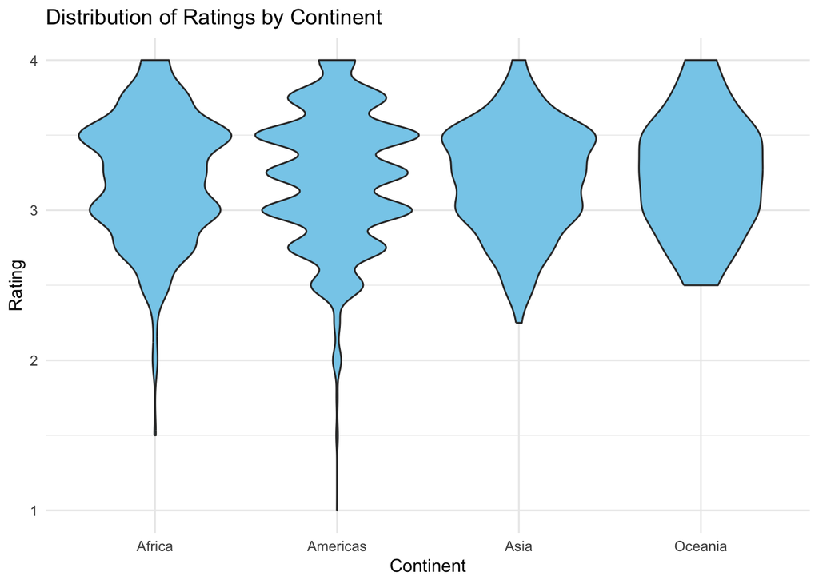

```r
ggplot(updated_merged_10_cleaned, aes(x = continent, y = rating)) +
  geom_violin(fill="skyblue") +
  labs(title = "Distribution of Ratings by Continent",
       x = "Continent",
       y = "Rating") +
  theme_minimal()
```

# Part 3: Convert wide data into long data

### 1.Create a new set of columns titled beans, sugar, cocoa_butter, vanilla, letchin, and salt that contain a 1 or 0 representing whether or not that review for the chocolate bar contained that ingredient (1) or not (0).

```r
chocolate %>%
  select(ingredients) %>%
  distinct()
```

```
## # A tibble: 22 × 1
##    ingredients
##    <chr>
##  1 3- B,S,C
##  2 4- B,S,C,L
##  3 2- B,S
##  4 4- B,S,C,V
##  5 5- B,S,C,V,L
##  6 6-B,S,C,V,L,Sa
##  7 5-B,S,C,V,Sa
##  8 <NA>
##  9 4- B,S,V,L
## 10 2- B,S*
## # ℹ 12 more rows
```

```r
## add new columns (Note that according to the data, if there's Sa, there must be S, so no worry about the repeated letter S.)
chocolate_add <- chocolate %>%
  mutate(
    beans = if_else(grepl("B", ingredients, ignore.case = FALSE), 1, 0),
    sugar = if_else(grepl("S", ingredients, ignore.case = FALSE), 1, 0),
    cocoa_butter = if_else(grepl("C", ingredients, ignore.case = FALSE), 1, 0),
    vanilla = if_else(grepl("V", ingredients, ignore.case = FALSE), 1, 0),
    letchin = if_else(grepl("L", ingredients, ignore.case = FALSE), 1, 0),
    salt = if_else(grepl("Sa", ingredients, ignore.case = FALSE), 1, 0),
  )
chocolate_add
```

```
## # A tibble: 2,530 × 16
##      ref company_manufacturer company_location review_date
##    <dbl> <chr>                <chr>                  <dbl>
##  1  2454 5150                 U.S.A.                  2019
##  2  2458 5150                 U.S.A.                  2019
##  3  2454 5150                 U.S.A.                  2019
##  4  2542 5150                 U.S.A.                  2021
##  5  2546 5150                 U.S.A.                  2021
##  6  2546 5150                 U.S.A.                  2021
##  7  2542 5150                 U.S.A.                  2021
##  8   797 A. Morin             France                  2012
##  9   797 A. Morin             France                  2012
## 10  1011 A. Morin             France                  2013
## # ℹ 2,520 more rows
## # ℹ 12 more variables: country_of_bean_origin <chr>,
## #   specific_bean_origin_or_bar_name <chr>, cocoa_percent <chr>,
## #   ingredients <chr>, most_memorable_characteristics <chr>, rating <dbl>,
## #   beans <dbl>, sugar <dbl>, cocoa_butter <dbl>, vanilla <dbl>, letchin <dbl>,
## #   salt <dbl>
```

### 2.Create a new set of columns titled char_cocoa, char_sweet, char_nutty, char_creamy, char_roasty, char_earthy that contain a 1 or 0 representing whether or not that the most memorable characteristic for the chocolate bar had that word (1) or not (0). For example, if the word “sweet” appears in the most_memorable_characteristics, then record a 1, otherwise a 0 for that review in the char_sweet column (Hint: check out str_detect() from the stringr package).

```r
chocolate_add_2 <- chocolate_add %>%
  mutate(
    char_cocoa = if_else(grepl("\\bcocoa\\b", most_memorable_characteristics, ignore.case = TRUE), 1, 0),
    char_sweet = if_else(grepl("\\bsweet\\b", most_memorable_characteristics, ignore.case = TRUE), 1, 0),
    char_nutty = if_else(grepl("\\bnutty\\b", most_memorable_characteristics, ignore.case = TRUE), 1, 0),
    char_creamy = if_else(grepl("\\bcreamy\\b", most_memorable_characteristics, ignore.case = TRUE), 1, 0),
    char_roasty = if_else(grepl("\\broasty\\b", most_memorable_characteristics, ignore.case = TRUE), 1, 0),
    char_earthy = if_else(grepl("\\bearthy\\b", most_memorable_characteristics, ignore.case = TRUE), 1, 0)
  )
chocolate_add_2
```

```
## # A tibble: 2,530 × 22
##      ref company_manufacturer company_location review_date
##    <dbl> <chr>                <chr>                  <dbl>
##  1  2454 5150                 U.S.A.                  2019
##  2  2458 5150                 U.S.A.                  2019
##  3  2454 5150                 U.S.A.                  2019
##  4  2542 5150                 U.S.A.                  2021
##  5  2546 5150                 U.S.A.                  2021
##  6  2546 5150                 U.S.A.                  2021
##  7  2542 5150                 U.S.A.                  2021
##  8   797 A. Morin             France                  2012
##  9   797 A. Morin             France                  2012
## 10  1011 A. Morin             France                  2013
## # ℹ 2,520 more rows
## # ℹ 18 more variables: country_of_bean_origin <chr>,
## #   specific_bean_origin_or_bar_name <chr>, cocoa_percent <chr>,
## #   ingredients <chr>, most_memorable_characteristics <chr>, rating <dbl>,
## #   beans <dbl>, sugar <dbl>, cocoa_butter <dbl>, vanilla <dbl>, letchin <dbl>,
## #   salt <dbl>, char_cocoa <dbl>, char_sweet <dbl>, char_nutty <dbl>,
## #   char_creamy <dbl>, char_roasty <dbl>, char_earthy <dbl>
```

### 3.For each year (i.e. review_date), calculate the mean value in each new column you created across all reviews for that year. (Hint: If all has gone well thus far, you should have a dataset with 16 rows and 13 columns).

```r
mean_score <- chocolate_add_2 %>%
  group_by(review_date) %>%
  summarise(beans=mean(beans),sugar=mean(sugar),cocoa_butter=mean(cocoa_butter),vanilla=mean(vanilla),letchin=mean(letchin),salt=mean(salt),char_cocoa=mean(char_cocoa),char_sweet=mean(char_sweet),char_nutty=mean(char_nutty),char_creamy=mean(char_creamy),char_roasty=mean(char_roasty),char_earthy=mean(char_earthy))
mean_score
```

```
## # A tibble: 16 × 13
##    review_date beans sugar cocoa_butter vanilla letchin    salt char_cocoa
##          <dbl> <dbl> <dbl>        <dbl>   <dbl>   <dbl>   <dbl>      <dbl>
##  1        2006 0.968 0.968        0.903  0.694   0.694  0           0.210
##  2        2007 0.945 0.945        0.767  0.548   0.384  0           0.342
##  3        2008 0.913 0.902        0.75   0.359   0.511  0           0.109
##  4        2009 0.919 0.919        0.772  0.325   0.341  0           0.146
##  5        2010 0.855 0.855        0.709  0.227   0.391  0.00909     0.218
##  6        2011 0.939 0.939        0.693  0.160   0.160  0.0491      0.172
##  7        2012 0.928 0.928        0.675  0.186   0.124  0.0722      0.0876
##  8        2013 0.967 0.956        0.776  0.208   0.295  0.0164      0.175
##  9        2014 0.984 0.984        0.644  0.0688  0.121  0.0324      0.0607
## 10        2015 0.986 0.979        0.546  0.0599  0.120  0           0.127
## 11        2016 0.982 0.977        0.594  0.0507  0.106  0.00922     0.0922
## 12        2017 0.981 0.981        0.562  0.0286  0.133  0.00952     0.133
## 13        2018 0.987 0.987        0.596  0.0614  0.132  0           0.180
## 14        2019 1     1            0.679  0.0259  0.202  0           0.259
## 15        2020 1     1            0.568  0.0370  0.0247 0           0.284
## 16        2021 1     0.994        0.646  0.0114  0.0800 0           0.297
## # ℹ 5 more variables: char_sweet <dbl>, char_nutty <dbl>, char_creamy <dbl>,
## #   char_roasty <dbl>, char_earthy <dbl>
```

### 4. Convert this wide dataset into a long dataset with a new feature and mean_score column.

```r
mean_score_long <- mean_score %>%
  pivot_longer(
    cols = c(beans,sugar,cocoa_butter,vanilla,letchin,salt,char_cocoa,char_sweet,char_nutty,char_creamy,char_roasty,char_earthy),
    names_to = "feature",
    values_to = "mean_score"
  )
mean_score_long
```

```
## # A tibble: 192 × 3
##    review_date feature      mean_score
##          <dbl> <chr>             <dbl>
##  1        2006 beans            0.968
##  2        2006 sugar            0.968
##  3        2006 cocoa_butter     0.903
##  4        2006 vanilla          0.694
##  5        2006 letchin          0.694
##  6        2006 salt             0
##  7        2006 char_cocoa       0.210
##  8        2006 char_sweet       0.161
##  9        2006 char_nutty       0.0323
## 10        2006 char_creamy      0.242
## # ℹ 182 more rows
```

# Part 4: Data visualization

### Use the functions in ggplot2 package to make a scatter plot of the mean_scores (y-axis) over time (x-axis). There should be one plot (facet) for each feature.

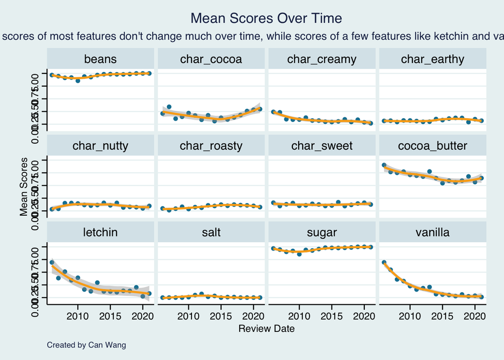

```r
ggplot(mean_score_long,aes(review_date,mean_score))+
  ggthemes::theme_stata()+
  geom_point(color="#1380A1")+
  geom_smooth(color="#FAAB18")+
  facet_wrap(. ~ feature)+
  labs(title = "Mean Scores Over Time",subtitle="Key Trends: Mean scores of most features don't change much over time, while scores of a few features like ketchin and vanilla decrease over time.") +
  labs(x = "Review Date",y = "Mean Scores",caption = "Created by Can Wang")
```

# Part 5: Make the worst plot you can!

### Make the absolute worst plot that you can. You need to customize it in at least 7 ways to make it awful.

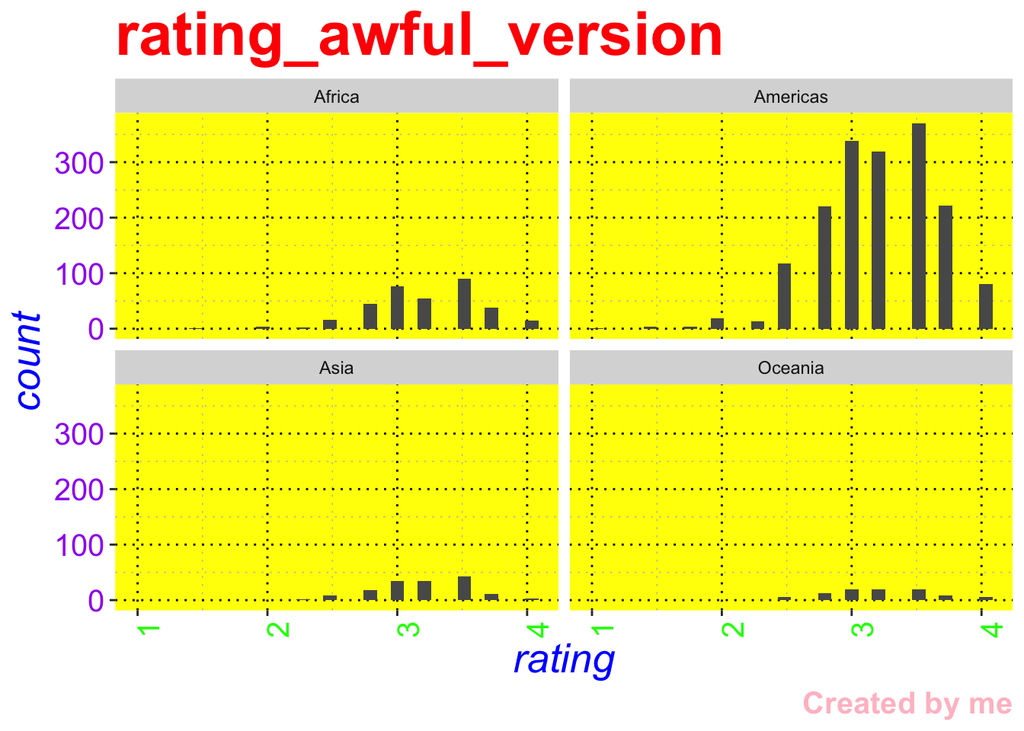

```r
updated_merged_10_cleaned %>%
  ggplot(aes(rating))+
  geom_histogram()+
  facet_wrap(. ~ continent)+
  labs(title="rating_awful_version",x="rating",y="count",caption="Created by me")+
  theme(
    plot.title = element_text(size = 30, face = "bold", color = "red"),
    axis.title.x = element_text(size = 20, face = "italic", color = "blue"),
    axis.title.y = element_text(size = 20, face = "italic", color = "blue"),
    panel.background = element_rect(fill = "yellow"),
    axis.text.x = element_text(size = 15, angle = 90, color = "green"),
    axis.text.y = element_text(size = 15, color = "purple"),
    panel.grid.major = element_line(color = "black", linetype = "dotted"),
    panel.grid.minor = element_line(color = "grey", linetype = "dotted"),
    plot.caption = element_text(size = 15, face = "bold", color = "pink"),
)
```

### Customizations:

1. Inconsistent color: too much color used, including red, blue, purple, pink and yellow, making the plot messy.
2. Inconsistent calligraphic style: the plot title and axis title use different style. Looks messy.
3. Inappropriate font size: The title and axis are too large while the continent names too small.
4. Unreadable title: The title contains “_“, which is not easy for people to read.
5. Inappropriate scale: the scale of the four histgrams are different, but we use the same axis. So it’s hard to see the distribution of Africa, Asia and Oceania.
6. Unnecessary grid lines: over complex grid lines.
7. Inappropriate caption: Caption too large and can be distracting.

If we want to make good data visualization, we should avoid these problems. We should use appropriate color and font size, use readable labels, and avoid unnecessary elements which are unrelated to the data.

# Part 6: Make my plot a better plot!

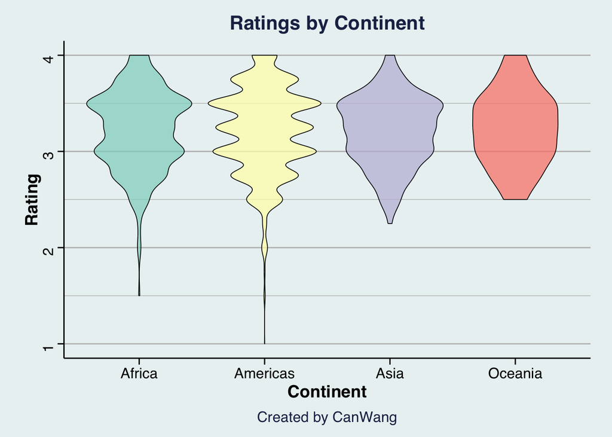

```r
updated_merged_10_cleaned %>%
  ggplot(aes(x = as.factor(continent), y = rating, fill = continent)) +
  geom_violin(alpha = 0.7, color = "black", size = 0.3) +
  scale_fill_brewer(palette = "Set3") +
  labs(
    title = "Ratings by Continent",
    x = "Continent",
    y = "Rating",
    caption = "Created by CanWang"
  ) +
  ggthemes::theme_stata() +
  theme(
    plot.title = element_text(size = 16, face = "bold", hjust = 0.5),
    plot.caption = element_text(size = 12, hjust = 0.5),
    axis.title.x = element_text(size = 14, face = "bold"),
    axis.title.y = element_text(size = 14, face = "bold"),
    axis.text.x = element_text(size = 12),
    axis.text.y = element_text(size = 12),
    legend.position = "none",
    panel.grid.major = element_line(color = "grey", size = 0.5),
    panel.grid.minor = element_line(color = "grey", size = 0.25),
    panel.background = element_blank()
  )
```